# KBcapstone

Import required libraries Import Machine Learning Model Random Forest Import Mean Squared Error

```python
import pandas as pd
import numpy as np
import matplotlib.pyplot as plt
import seaborn as sns

from sklearn.model_selection import GroupShuffleSplit, train_test_split
from sklearn.ensemble import RandomForestRegressor
from sklearn.metrics import mean_squared_error
```

Define column names prior to loading training data Read training data FD0001.txt and assign column names to DataFrame df_train Preview data of DataFrame df_train for verification

```python
col_names = ['unit_number', 'time_in_cycles',
             'op_setting_1', 'op_setting_2', 'op_setting_3'] \
             + [f'sensor_{i+1}' for i in range(26)]

df_train = pd.read_csv("train_FD001.txt", sep="\\s+", header=None, names=col_names)

df_train.head()
```

|  | unit_number | time_in_cycles | op_setting_1 | op_setting_2 | op_setting_3 | sensor_1 | sensor_2 | sensor_3 | sensor_4 | sensor_5 | ... | sensor_17 | sensor_18 | sensor_19 | sensor_20 | sensor_21 | sensor_22 | sensor_23 | sensor_24 | sensor_25 | sensor_26 |
| --- | --- | --- | --- | --- | --- | --- | --- | --- | --- | --- | --- | --- | --- | --- | --- | --- | --- | --- | --- | --- | --- |
| 0 | 1 | 1 | -0.0007 | -0.0004 | 100.0 | 518.67 | 641.82 | 1589.70 | 1400.60 | 14.62 | ... | 392 | 2388 | 100.0 | 39.06 | 23.4190 | NaN | NaN | NaN | NaN | NaN |
| 1 | 1 | 2 | 0.0019 | -0.0003 | 100.0 | 518.67 | 642.15 | 1591.82 | 1403.14 | 14.62 | ... | 392 | 2388 | 100.0 | 39.00 | 23.4236 | NaN | NaN | NaN | NaN | NaN |
| 2 | 1 | 3 | -0.0043 | 0.0003 | 100.0 | 518.67 | 642.35 | 1587.99 | 1404.20 | 14.62 | ... | 390 | 2388 | 100.0 | 38.95 | 23.3442 | NaN | NaN | NaN | NaN | NaN |
| 3 | 1 | 4 | 0.0007 | 0.0000 | 100.0 | 518.67 | 642.35 | 1582.79 | 1401.87 | 14.62 | ... | 392 | 2388 | 100.0 | 38.88 | 23.3739 | NaN | NaN | NaN | NaN | NaN |
| 4 | 1 | 5 | -0.0019 | -0.0002 | 100.0 | 518.67 | 642.37 | 1582.85 | 1406.22 | 14.62 | ... | 393 | 2388 | 100.0 | 38.90 | 23.4044 | NaN | NaN | NaN | NaN | NaN |

5 rows × 31 columns

Define maximum cycles per engine Merge onto df_train to define Remaining Useable Life (RUL) Preview data of df_train with RUL for verification

```python
max_cycles = df_train.groupby('unit_number')['time_in_cycles'].max().reset_index()
max_cycles.columns = ['unit_number', 'max_cycles']

df_train = df_train.merge(max_cycles, on='unit_number')
df_train['RUL'] = df_train['max_cycles'] - df_train['time_in_cycles']

df_train[['unit_number', 'time_in_cycles', 'RUL']].head()
```

|  | unit_number | time_in_cycles | RUL |
| --- | --- | --- | --- |
| 0 | 1 | 1 | 191 |
| 1 | 1 | 2 | 190 |
| 2 | 1 | 3 | 189 |
| 3 | 1 | 4 | 188 |
| 4 | 1 | 5 | 187 |

Read and describe DataFrame with mean, standard deviation, minimum, and maximum

```python
df_train.describe().T[['mean','std','min','max']]
```

|  | mean | std | min | max |
| --- | --- | --- | --- | --- |
| unit_number | 51.506568 | 2.922763e+01 | 1.0000 | 100.0000 |
| time_in_cycles | 108.807862 | 6.888099e+01 | 1.0000 | 362.0000 |
| op_setting_1 | -0.000009 | 2.187313e-03 | -0.0087 | 0.0087 |
| op_setting_2 | 0.000002 | 2.930621e-04 | -0.0006 | 0.0006 |
| op_setting_3 | 100.000000 | 0.000000e+00 | 100.0000 | 100.0000 |
| sensor_1 | 518.670000 | 0.000000e+00 | 518.6700 | 518.6700 |
| sensor_2 | 642.680934 | 5.000533e-01 | 641.2100 | 644.5300 |
| sensor_3 | 1590.523119 | 6.131150e+00 | 1571.0400 | 1616.9100 |
| sensor_4 | 1408.933782 | 9.000605e+00 | 1382.2500 | 1441.4900 |
| sensor_5 | 14.620000 | 5.329200e-15 | 14.6200 | 14.6200 |
| sensor_6 | 21.609803 | 1.388985e-03 | 21.6000 | 21.6100 |
| sensor_7 | 553.367711 | 8.850923e-01 | 549.8500 | 556.0600 |
| sensor_8 | 2388.096652 | 7.098548e-02 | 2387.9000 | 2388.5600 |
| sensor_9 | 9065.242941 | 2.208288e+01 | 9021.7300 | 9244.5900 |
| sensor_10 | 1.300000 | 0.000000e+00 | 1.3000 | 1.3000 |
| sensor_11 | 47.541168 | 2.670874e-01 | 46.8500 | 48.5300 |
| sensor_12 | 521.413470 | 7.375534e-01 | 518.6900 | 523.3800 |
| sensor_13 | 2388.096152 | 7.191892e-02 | 2387.8800 | 2388.5600 |
| sensor_14 | 8143.752722 | 1.907618e+01 | 8099.9400 | 8293.7200 |
| sensor_15 | 8.442146 | 3.750504e-02 | 8.3249 | 8.5848 |
| sensor_16 | 0.030000 | 3.469531e-18 | 0.0300 | 0.0300 |
| sensor_17 | 393.210654 | 1.548763e+00 | 388.0000 | 400.0000 |
| sensor_18 | 2388.000000 | 0.000000e+00 | 2388.0000 | 2388.0000 |
| sensor_19 | 100.000000 | 0.000000e+00 | 100.0000 | 100.0000 |
| sensor_20 | 38.816271 | 1.807464e-01 | 38.1400 | 39.4300 |
| sensor_21 | 23.289705 | 1.082509e-01 | 22.8942 | 23.6184 |
| sensor_22 | NaN | NaN | NaN | NaN |
| sensor_23 | NaN | NaN | NaN | NaN |
| sensor_24 | NaN | NaN | NaN | NaN |
| sensor_25 | NaN | NaN | NaN | NaN |
| sensor_26 | NaN | NaN | NaN | NaN |
| max_cycles | 216.615724 | 5.002860e+01 | 128.0000 | 362.0000 |
| RUL | 107.807862 | 6.888099e+01 | 0.0000 | 361.0000 |

Display a heatmap displaying which sensors have the largest effect on the RUL

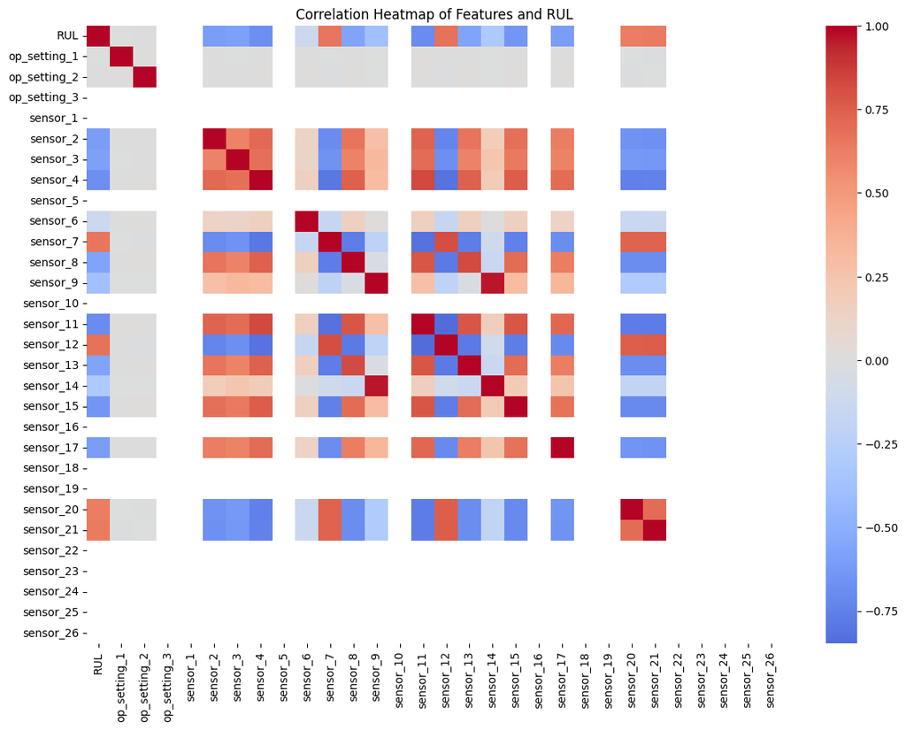

```python
plt.figure(figsize=(14,10))
sns.heatmap(df_train[['RUL'] + col_names[2:]].corr(), cmap="coolwarm", center=0)
plt.title("Correlation Heatmap of Features and RUL")
plt.show()
```

Define columns for DataFrame training set

```python
feature_cols = ['op_setting_1','op_setting_2','op_setting_3'] + [f'sensor_{i+1}' for i in range(26)]
X = df_train[feature_cols]
y = df_train['RUL']
```

Define a group for DataFrame unit number Group Shuffle Split group to prevent data leakage between training and testing sets Define X and Y training and validating sets

```python
groups = df_train['unit_number']
gss = GroupShuffleSplit(n_splits=1, test_size=0.2, random_state=42)
train_idx, val_idx = next(gss.split(X, y, groups=groups))

X_train, X_val = X.iloc[train_idx], X.iloc[val_idx]
y_train, y_val = y.iloc[train_idx], y.iloc[val_idx]
```

Define Random Forest Regressor Model and fit X and Y training data Define predicted Y value Define and perform Root Mean Squeared Error (RMSE) calculation Print RMSE in cycles

```python
rf = RandomForestRegressor(n_estimators=150, random_state=42, n_jobs=-1)
rf.fit(X_train, y_train)

y_pred = rf.predict(X_val)
rmse = np.sqrt(mean_squared_error(y_val, y_pred))
print(f"Validation RMSE: {rmse:.2f} cycles")
```

```
Validation RMSE: 35.50 cycles
```

Define absolute errors and plot displaying Predicted vs Actual RUL

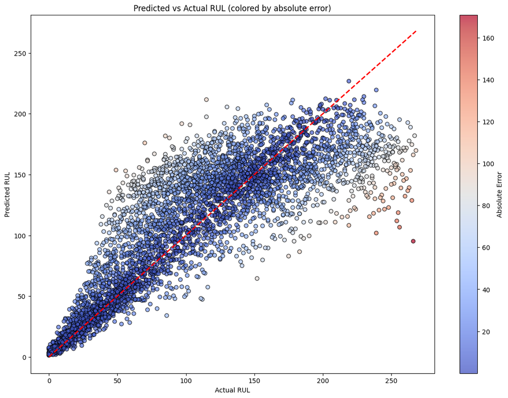

```python
errors = np.abs(y_val - y_pred)

plt.figure(figsize=(14,10))
sc = plt.scatter(y_val, y_pred, c=errors, cmap="coolwarm", edgecolor="k", alpha=0.7)
plt.plot([y_val.min(), y_val.max()], [y_val.min(), y_val.max()], 'r--', lw=2)
plt.xlabel("Actual RUL")
plt.ylabel("Predicted RUL")
plt.title("Predicted vs Actual RUL (colored by absolute error)")
plt.colorbar(sc, label="Absolute Error")
plt.show()
```

Define the more important features (sensors) and plot

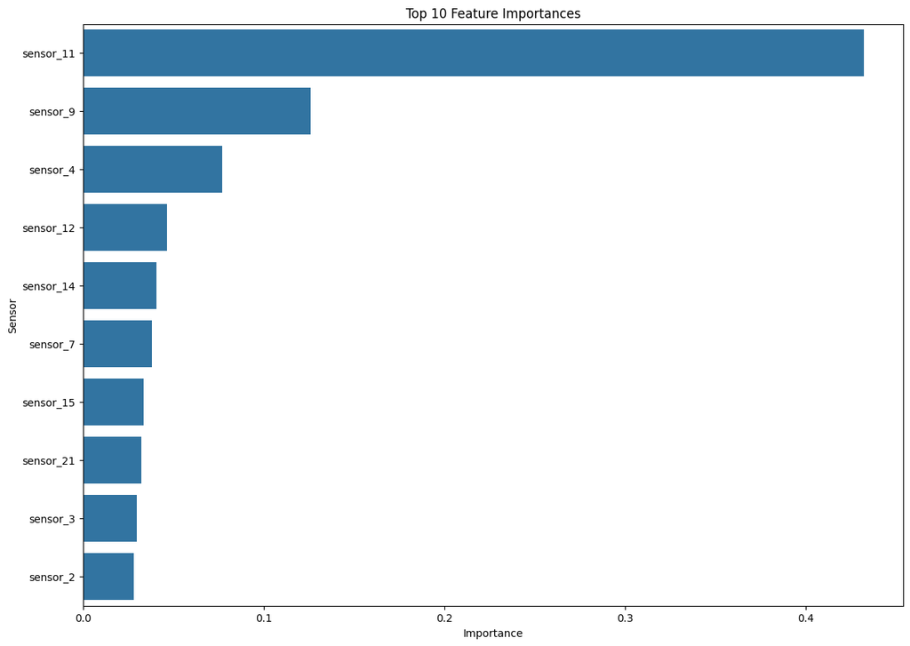

```python
importances = rf.feature_importances_
feat_imp = pd.Series(importances, index=feature_cols).sort_values(ascending=False).head(10)

plt.figure(figsize=(14,10))
sns.barplot(x=feat_imp.values, y=feat_imp.index, legend=False)
plt.title("Top 10 Feature Importances")
plt.xlabel("Importance")
plt.ylabel("Sensor")
plt.show()
```

Sort the values of Unit Number and Time in Cycles Define new features for sensors changing over time, deltas

```python
df_train_sorted = df_train.sort_values(['unit_number','time_in_cycles']).copy()
for c in feature_cols:
    df_train_sorted[c+"_delta"] = df_train_sorted.groupby('unit_number')[c].diff().fillna(0)

X_fe = df_train_sorted[feature_cols + [c+"_delta" for c in feature_cols]]
y_fe = df_train_sorted['RUL']
```

Test and predict to test set FD001.txt

```python
df_test = pd.read_csv("test_FD001.txt", sep="\\s+", header=None, names=col_names)
true_rul = pd.read_csv("RUL_FD001.txt", sep="\\s+", header=None).squeeze("columns")

last_rows = df_test.groupby('unit_number').tail(1)
X_test_last = last_rows[feature_cols]
y_test_pred = rf.predict(X_test_last)

test_rmse = np.sqrt(mean_squared_error(true_rul, y_test_pred))
print(f"Test RMSE: {test_rmse:.2f} cycles")
```

```
Test RMSE: 34.32 cycles
```

Define and Test NASA score for over/under estimates against high/low RUL

```python
def nasa_score(y_true, y_hat):
    d = y_hat - y_true
    over = d[d >= 0]
    under = d[d < 0]
    s_over = (np.exp(over/10) - 1).sum()
    s_under = (np.exp(-under/13) - 1).sum()
    return s_over + s_under

print("NASA Score:", nasa_score(true_rul.values, test_pred))
```

```
NASA Score: 57865.96286503829
```

```python
import pickle, json

with open("rf_fd001.pkl", "wb") as f:
    pickle.dump(rf, f)

with open("feature_cols.json", "w") as f:
    json.dump(feature_cols, f)

print("Saved: rf_fd001.pkl, feature_cols.json")
```

```
Saved: rf_fd001.pkl, feature_cols.json
```